# Reproducible Research: Peer Assessment 1

Sergey Kosenko

07/07/2015

#### System information:

R version 3.2.0 (2015-04-16) – “Full of Ingredients”  
Platform: i386-w64-mingw32/i386 (32-bit)  
OS: Windows 8

### Introduction

In this assignment we study how to make a reproducible research with using a tools of R programming language and create R markdown papers and reports by method Literate Statistical Programming.

### Source data

It is now possible to collect a large amount of data about personal movement using activity monitoring devices such as a Fitbit, Nike Fuelband, or Jawbone Up. These type of devices are part of the “quantified self” movement – a group of enthusiasts who take measurements about themselves regularly to improve their health, to find patterns in their behavior, or because they are tech geeks. But these data remain under-utilized both because the raw data are hard to obtain and there is a lack of statistical methods and software for processing and interpreting the data.

This assignment makes use of data from a personal activity monitoring device. This device collects data at 5 minute intervals through out the day. The data consists of two months of data from an anonymous individual collected during the months of October and November, 2012 and include the number of steps taken in 5 minute intervals each day.

The data (Dataset: Activity monitoring data [52K]) for this assignment downloaded from the course web site. The variables included in this dataset are: steps: Number of steps taking in a 5-minute interval (missing values are coded as NA) date: The date on which the measurement was taken in YYYY-MM-DD format interval: Identifier for the 5-minute interval in which measurement was taken The dataset is stored in a comma-separated-value (CSV) file and there are a total of 17,568 observations in this dataset.

### Preparation phase

My native locale is not English. Changing locale and language to English:

```r
Sys.setlocale("LC_TIME", "eng") # set the system locale
Sys.setenv(LANG = "en")         # set the English language
```

Code chunk for checking of existing the dataset and download if it not exist:

```r
if (!file.exists("./activity.csv") | !file.exists("activity.csv")) {
    print("Original files not found. Downloading data")
    fileUrl <- "http://d396qusza40orc.cloudfront.net/repdata%2Fdata%2Factivity.zip"
    download.file(fileUrl,destfile="./Dataset.zip",method="auto")
    unzip(zipfile="./Dataset.zip")
} else {
    print("Data set exists")
}
```

Include necessary libraries and setting options:

```r
library(ggplot2) # for ggplot graph
library(lattice) # for lattice plot
options(scipen=1, digits=2) # number of decimals
```

### Analysis phase

After successful download we can start analysis:  
STEP 1: Loading and preprocessing the data  
Assignment:  
1.1 Show any code that is needed to load the data (i.e. read.csv())  
1.2 Process/transform the data (if necessary) into a format suitable for your analysis

```r
# Decision:
# 1.1-1.2 Reading dataset from file and transform the data into a suitable format:
all_data <- read.csv("./activity.csv")
all_data$date <- as.Date(all_data$date, format="%Y-%m-%d")
```

STEP 2: What is mean total number of steps taken per day?  
Assignment:  
For this part of the assignment, you can ignore the missing values in the dataset.  
2.1 Calculate the total number of steps taken per day  
2.2 If you do not understand the difference between a histogram and a barplot, research the difference between them.  
Make a histogram of the total number of steps taken each day  
2.3 Calculate and report the mean and median of the total number of steps taken per day

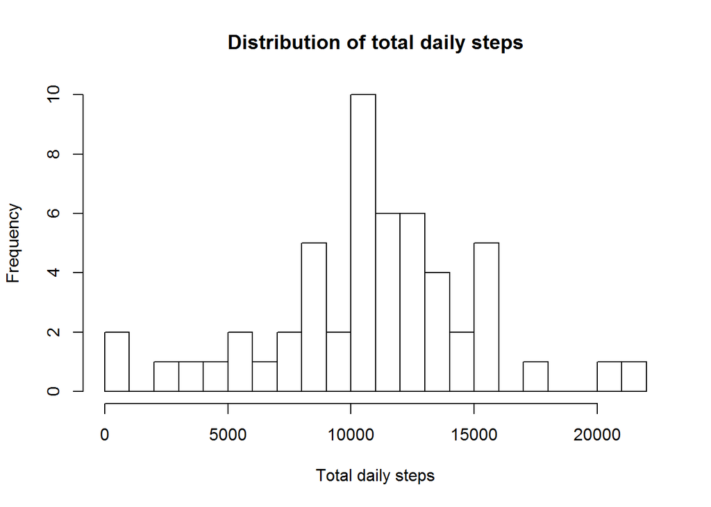

```r
# Decision:
# Excluding missing values from dataset:
    data_wna <- all_data[complete.cases(all_data),]

#2.1 Calculating the total number of steps taken per day:
    steps_date <- aggregate(steps ~ date, data = data_wna, FUN = "sum")

#2.2 Making a histogram of the total number of steps taken each day:
    # 2.2.1 Finding a count of breaks for histogram
    break1 <- round((max(steps_date$steps) - min(steps_date$steps))/1000, 0) + 2
    # 2.2.2 Make a histogram
    hist(steps_date$steps, breaks = break1, main = "Distribution of total daily steps",
    xlab = "Total daily steps", ylab = "Frequency")
```

```r
#2.3 Calculate and report the mean and median total number of steps taken per day
    mean_steps <- mean(steps_date$steps)        # [1] 10766.19
    median_steps <- median(steps_date$steps)    # [1] 10765
```

```
 Report:   \
 Mean total number of steps taken per day: 10766.19
 Median total number of steps taken per day: 10765
```

STEP 3: What is the average daily activity pattern?  
Assignment:  
3.1 Make a time series plot (i.e. type = “l”) of the 5-minute interval (x-axis)  
and the average number of steps taken, averaged across all days (y-axis)  
3.2 Which 5-minute interval, on average across all the days in the dataset, contains the maximum number of steps?

```
 Decision:
 3.1 Make a time series plot
 Primarily we must prepare time series data.
 "interval" data (type: integer) in the end of hour and start of the next hour have data: ... 55 100 ...
 If we plot a graph with this data as integer numbers then between points 55 and 100 will be a gap,
 In line plot this gap is filled a straight line from (55 to 100). For time intervals that do not exist,
 because real time data goes only from 0 to 60 every hour.
 Therefore we must convert integer interval data into time interval data with next code:
```

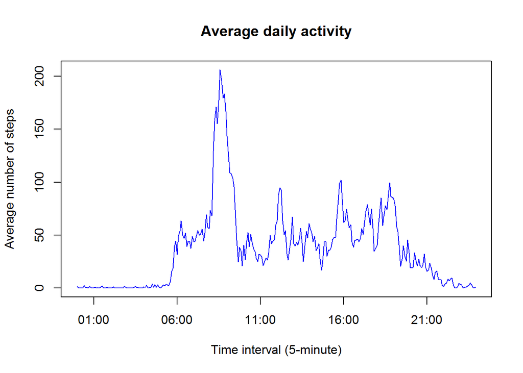

```r
    # 3.1.1 Getting average numbers of steps by 5-minute intervals across all days
    steps_mean5 <- aggregate(steps ~ interval, data = all_data, FUN = "mean")
    # 3.1.2 Setup "4 digits length" format for interval data
    steps_mean5$interval <- sprintf("%04d", steps_mean5$interval)
    # 3.1.3 Convert "4 digits data" to datetime data
    steps_mean5$interval <- strptime(steps_mean5$interval, format="%H%M")
    # Make a plot:
    plot(steps_mean5$interval, steps_mean5$steps, type = "l", col = "blue",
    main = "Average daily activity", xlab = "Time interval (5-minute)", ylab = "Average number of steps")
```

```r
     # 3.2 Which 5-minute interval, on average across all the days in the dataset,
     # contains the maximum number of steps?
     steps_mean5$interval <- strftime(steps_mean5$interval, format="%H:%M")
     steps_mean5[which.max(steps_mean5$steps),][[1]]
```

```
 Report: 08:35 is interval with maximum number of steps across all the days in the dataset
```

STEP 4: Imputing missing values  
Assignment:  
Note that there are a number of days/intervals where there are missing values (coded as NA).  
The presence of missing days may introduce bias into some calculations or summaries of the data.  
4.1 Calculate and report the total number of missing values in the dataset (i.e. the total number of rows with NAs)  
4.2 Devise a strategy for filling in all of the missing values in the dataset.  
The strategy does not need to be sophisticated. For example, you could use the mean/median for that day,  
or the mean for that 5-minute interval, etc.  
4.3 Create a new dataset that is equal to the original dataset but with the missing data filled in.  
4.4 Make a histogram of the total number of steps taken each day  
4.5 Calculate and report the mean and median total number of steps taken per day.  
Do these values differ from the estimates from the first part of the assignment?  
What is the impact of imputing missing data on the estimates of the total daily number of steps?

```r
     # Decision:
     # 4.1 Calculate and report the total number of missing values in the dataset
     # (i.e. the total number of rows with NAs)
     na_count <- sum(!complete.cases(all_data)) # Count of incomplete cases
```

```
 Report: 2304 is total number of rows with NAs.
```